# Arrests and Calls for Service in Baltimore

In an earlier notebook I examined the nature of arrests in Baltimore, Maryland, by creating various visualizations that used the city’s [Part I arrests](https://data.baltimorecity.gov/Public-Safety/BPD-Part-1-Victim-Based-Crime-Data/wsfq-mvij) open dataset.

Among the feedback I received on this notebook was a suggestion to use the city’s [Calls for Service](https://data.baltimorecity.gov/Public-Safety/911-Calls-for-Service/xviu-ezkt) dataset to look at the distribution of 911 calls across the city, as well as the relationship between arrests and calls for service. Of particular interest is whether there is a difference, across neighborhoods, in the number of arrests that originate from a 911 call versus otherwise (e.g., officers observing potential criminal activity while on patrol).

It is important to note that the Part I Arrest and Call for Service datasets are not directly linked. That is, there is no shared identifier in the datasets that would allow us to associate each arrest that originated from a 911 call (via dispatch) with the corresponding Call for Service record.We are, however, able to look at the relationship between Calls for Service and Arrests in the aggregate for various geographic areas of the city. Like the Arrest dataset, the Call for Service dataset includes approximate latitude/longitude coordinates for the incident location. This allows us to overlay the calls for service onto the city’s neighborhood shapefile and the US Census Bureau census tract shapefile, just as we did in the previous notebook analysis. Then we can, for each geographic area, compute a ratio of the number of arrests to the number of calls for service to get a sense of the relationship.

It will be key to exercise some caution in interpreting this ratio, since there are many factors that could explain a difference in the ratio across neighborhoods. If Neighborhood A sees 3 arrests per hundred 911 calls (somewhat below the city-wide average, as we will see shortly), and Neighborhood B sees 6 arrests per 100 calls, it could be the case that the police department is devoting more resources to patrolling Neighborhood B, leading to more officer-observed activity that results in an arrest without an underlying service call. Or it could be that the inhabitants of Neighborhood A are more able, willing, or otherwise likely to report incidents to the city by calling 911 than the inhabitants of Neighborhood B. Alternatively, the calls for service in Neighborhood A may involve a greater proportion of incidents that tend not to lead to arrest, such as traffic accidents, nuisance calls, medical emergencies, and the like. There is not much in the dataset that allows us to tease out these factors, but perhaps we can nonetheless gain some useful insights about the nature of crime in Baltimore that can be explored further in future analyses.

## Dataset Summary

The Calls for Service dataset that I used in this notebook has 2,514,489 records covering the period 01/01/2015 to 06/17/2017. Each record contains:

- The date and time of the call
- The priority of the call (Emergency, High, Low, Medium, Non-Emergency, Out of Service)
- A description of the call (which appears to be quasi-free text)
- Location information, which includes the district and approximate address and coordinates of the incident
- A call identifier

I subsetted the raw dataset to cover the same date range as the Part I Arrest dataset used in the prior notebook, and removed any records with missing values for call date/time or location coordinates.

For details on how I read in the raw dataset and integrated it with the other data sources used in the notebook, see the [`Baltimore-ReadData.R` script](https://github.com/scottcame/police-data/blob/master/Baltimore-ReadData.R) in the GitHub repository.

## Distribution of Calls for Service by Priority

To get an initial feel for the dataset, consider the following bar chart depicting the priority level of calls:

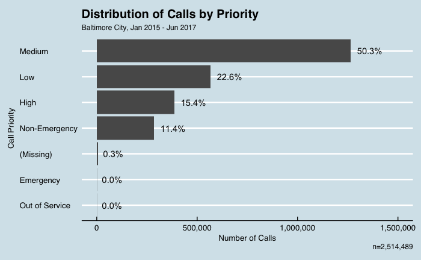

```r
CallsForService %>% group_by(priority) %>% summarize(n=n()) %>% mutate(pct=n/sum(n), pcts=percent(pct)) %>%
  mutate(priority=ifelse(is.na(priority), '(Missing)', priority)) %>%
  ggplot() +
  geom_bar(mapping=aes(x=reorder(priority, n), y=n), stat='identity') + coord_flip() +
  stat_summary(fun.y = identity, geom="text", aes(x=reorder(priority, n), y=n, label=pcts), hjust = -.25) +
  scale_y_continuous(labels=comma, limits=c(0,1500000)) +
  theme_economist() +
  labs(x='Call Priority', y='Number of Calls', title='Distribution of Calls by Priority',
       subtitle=paste0('Baltimore City, ', minDateS, ' - ', maxDateS),
       caption=paste0('n=', comma(nrow(CallsForService))))
```

Since the city’s dataset documentation does not define the rules used to assign these priority labels to calls, it is somewhat difficult to interpret the distribution. As the bar chart indicates, a slight majority of all calls (and by far the largest category) is “Medium” priority.

We can also look at the distribution of calls by priority across the city. In this choropleth map, we have taken the ratio of “Emergency” and “High” priority calls, in the numerator, to the number of “Low” priority calls, in the denominator:

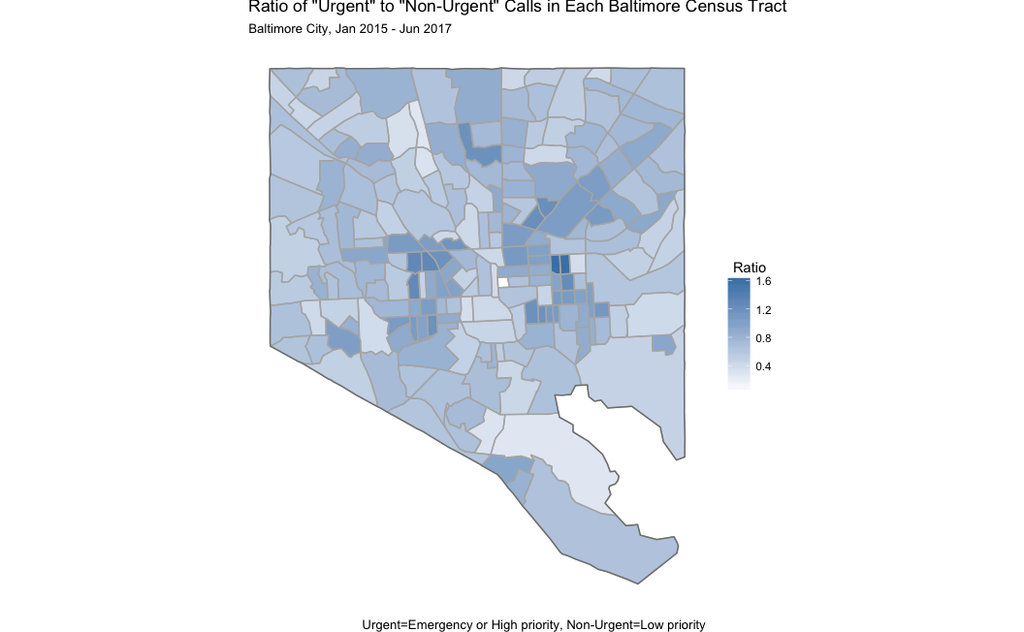

```r
CensusBlockSDF %>%
  ggplot(mapping=aes(x=long, y=lat, group=group)) +
    geom_polygon(aes(fill=UrgentCallRatio)) +
    geom_path(color='grey70') +
    geom_path(data=CountySDF, color='grey50') +
    scale_fill_gradient(low = "white",high = "steelblue", na.value='grey90') +
    coord_map() +
    theme_void() +
  theme(legend.title.align=0.5) +
  labs(fill='Ratio',
       title='Ratio of "Urgent" to "Non-Urgent" Calls in Each Baltimore Census Tract',
       caption='Urgent=Emergency or High priority, Non-Urgent=Low priority',
       subtitle=paste0('Baltimore City, ', minDateS, ' - ', maxDateS))
```

There is considerable variation across Census tracts in the relative proportion of urgent calls, with several areas to the west and east of downtown, the Belair area northeast of downtown, and the tract to the southwest of Johns Hopkins University all having more urgent than non-urgent calls. Conversely, along the outer edges of the city, non-urgent calls are relatively more frequent.